# Figures 1

Audrey Bahr

2/10/21

```r
library(colorspace)
```

3/29

```r
getwd()
setwd("/Users/audrey/Desktop/Current Projects/COVID/teacher_SEIR-master/outputs_test/scenario_idx_0")
getwd()
infect_cur_tot_0 <- read_csv("count_scenario_idx_0_current_symp_inf_Total.csv", col_names = TRUE)
# count_scenario_idx_0_current_symp_inf_Total.csv
```

```r
setwd("/Users/audrey/Desktop/Current Projects/COVID/teacher_SEIR-master/outputs_test/scenario_idx_0")
infect_cumul_tot_0 <- read_csv("count_scenario_idx_0_cumulative_symp_inf_Total.csv", col_names = TRUE)
```

(Automate this) Load in all files for the different age groups

```r
file_name <- function(rate_count, s_num, cumul_curr, type, ag) {
  lab <- glue("{rate_count}_scenario_idx_{s_num}_{cumul_curr}_{type}_{ag}.csv")
  return(lab)
}
```

```r
read_files <- function(rate_count, s_num, cumul_curr, type) {
  wd <- glue("/Users/audrey/Desktop/Current Projects/COVID/teacher_SEIR-master/outputs_test/scenario_idx_{s_num}")
setwd(wd)
files <- list()
for (i in 1:12) {

  ag <- new_names[i+2]
  files[i] <- file_name(rate_count, s_num, cumul_curr, type, ag)

}

for (i in 1:12) {

  assign(paste0(type, cumul_curr, s_num, new_names[i+2]), read_csv(files[[i]], col_names = TRUE))
}

}
```

Add medians by rows eg. for T files, add all medians for 2020-02-15

```r
t_median <- `infect018-25 T`$median + `infect026-49 T`$median + `infect050-64 T`$median + `infect065+ T`$median

s_median <- `infect018-25 S`$median + `infect026-49 S`$median + `infect050-64 S`$median + `infect065+ S`$median

x_median <- `infect018-25 X`$median + `infect026-49 X`$median + `infect050-64 X`$median + `infect065+ X`$median
```

New column - divide total by employment population (from Austin_pop) (Calculate employment population first)

```r
t_pop <- sum(austin_pop$X18.25.T, austin_pop$X26.49.T, austin_pop$X50.64.T, austin_pop$X65..T)

s_pop <- sum(austin_pop$X18.25.S, austin_pop$X26.49.S, austin_pop$X50.64.S, austin_pop$X65..S)

x_pop <- sum(austin_pop$X18.25.X, austin_pop$X26.49.X, austin_pop$X50.64.X, austin_pop$X65..X)
```

```r
t_rate <- t_median / t_pop

s_rate <- s_median / s_pop

x_rate <- x_median / x_pop
```

Plot calculated rates on line graph. Rate vs date, colored by employment group.

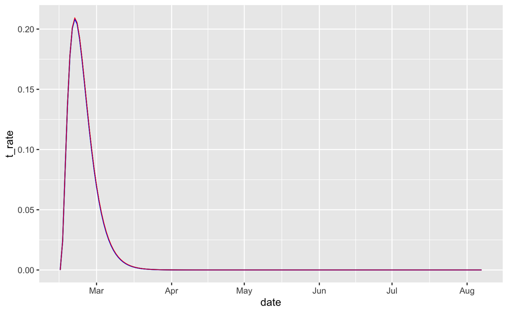

Repeat

```r
rate_count <- "count"
s_num <- "0"
option <- "cumulative"
type <- "infections"

wd <- glue("/Users/audrey/Desktop/Current Projects/COVID/teacher_SEIR-master/outputs_test/scenario_idx_{s_num}")
setwd(wd)
files <- list()
for (i in 1:12) {

  ag <- new_names[i+2]
  files[i] <- file_name(rate_count, s_num, option, type, ag)

}

for (i in 1:12) {

  assign(paste0(type, option, s_num, new_names[i+2]), read_csv(files[[i]], col_names = TRUE))
}
```

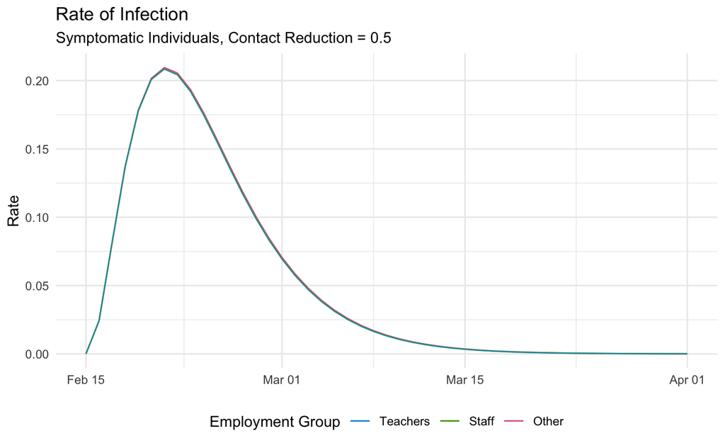

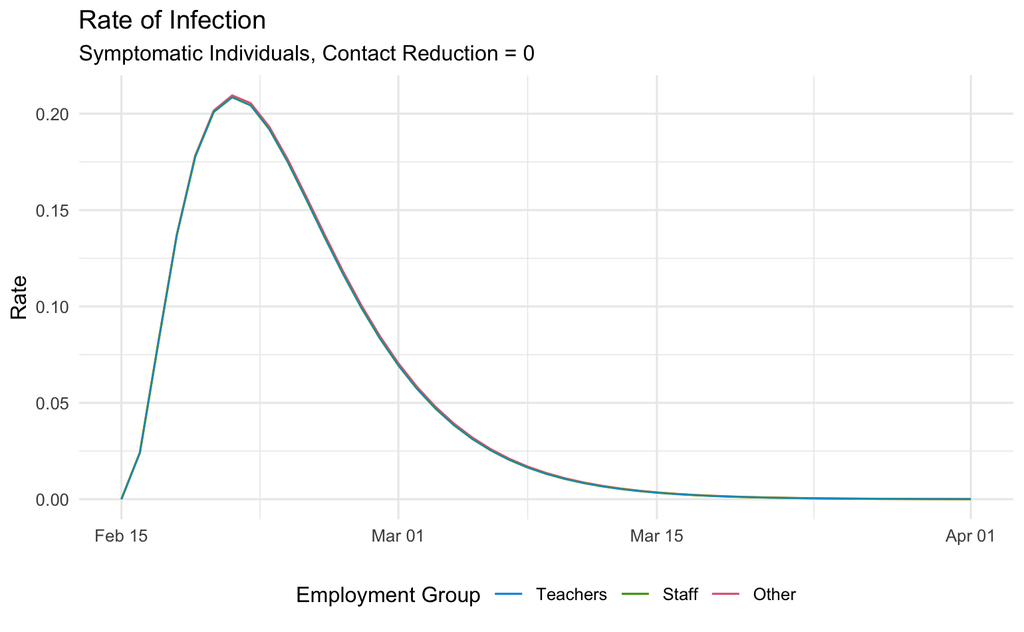

Why are the plots for scenario 0 and scenario 2 the same?

sd = 1

```r
t_rate <- (`symp_infcurrent418-25 T`$median + `symp_infcurrent426-49 T`$median + `symp_infcurrent450-64 T`$median + `symp_infcurrent465+ T`$median) / t_pop

s_rate <- (`symp_infcurrent418-25 S`$median + `symp_infcurrent426-49 S`$median + `symp_infcurrent450-64 S`$median + `symp_infcurrent465+ S`$median) / s_pop

x_rate <- (`symp_infcurrent418-25 X`$median + `symp_infcurrent426-49 X`$median + `symp_infcurrent450-64 X`$median + `symp_infcurrent465+ X`$median) / x_pop

sympinf_4_plot <- data.frame(cbind(select(`infect018-25 S`, date), t_rate, s_rate, x_rate))

ggplot(sympinf_4_plot, aes(date, x_rate, color = "Other")) + geom_line() + geom_line(aes(date, s_rate, color = "Staff")) + geom_line(aes(date, t_rate, color = "Teachers"), size = .3) + theme_minimal() + ggtitle("Rate of Infection", subtitle = "Symptomatic Individuals, Contact Reduction = 1") + xlab(NULL) + ylab("Rate") + scale_color_discrete_qualitative() + labs(color = "Employment Group") + guides(color = guide_legend(reverse=TRUE)) + scale_x_date(limits = c(as.Date("2020-02-15"), as.Date("2020-04-01")))
```

[output not shown]

Cumulative Infections

```r
t_rate <- (`infectionscumulative018-25 T`$median + `infectionscumulative026-49 T`$median + `infectionscumulative050-64 T`$median + `infectionscumulative065+ T`$median) / t_pop

s_rate <- (`infectionscumulative018-25 S`$median + `infectionscumulative026-49 S`$median + `infectionscumulative050-64 S`$median + `infectionscumulative065+ S`$median) / s_pop

x_rate <- (`infectionscumulative018-25 X`$median + `infectionscumulative026-49 X`$median + `infectionscumulative050-64 X`$median + `infectionscumulative065+ X`$median) / x_pop

infcumul_0_plot <- data.frame(cbind(select(`infect018-25 S`, date), t_rate, s_rate, x_rate))

ggplot(infcumul_0_plot, aes(date, x_rate, color = "Other")) + geom_line() + geom_line(aes(date, s_rate, color = "Staff")) + geom_line(aes(date, t_rate, color = "Teachers"), size = .3) + theme_minimal() + ggtitle("Cumulative Rate of Infection", subtitle = "Symptomatic Individuals, Contact Reduction = 0") + xlab(NULL) + ylab("Rate") + scale_color_discrete_qualitative() + labs(color = "Employment Group") + guides(color = guide_legend(reverse=TRUE)) + scale_x_date(limits = c(as.Date("2020-02-15"), as.Date("2020-04-01")))
```

[output not shown]

Adding child groups on.

```r
setwd("/Users/audrey/Desktop/Current Projects/COVID/teacher_SEIR-master/outputs_test/scenario_idx_0")
infectionscumulative004 <- read_csv("count_scenario_idx_0_cumulative_infections_0-4.csv", col_names = TRUE)
infectionscumulative0517 <- read_csv("count_scenario_idx_0_cumulative_infections_5-17.csv", col_names = TRUE)
```

[figure not shown]

```r
k1_rate <- infectionscumulative004$median / (austin_pop[1,3] + austin_pop[2,3])

k2_rate <- infectionscumulative0517$median / (austin_pop[1,4] + austin_pop[2,4])

infcumul_0_plot.2 <- cbind(infcumul_0_plot, k1_rate, k2_rate)

ggplot(infcumul_0_plot.2, aes(date, x_rate, color = "Other")) + geom_line() + geom_line(aes(date, s_rate, color = "Staff")) + geom_line(aes(date, t_rate, color = "Teachers")) + geom_line(aes(date, k1_rate, color = "Kids (0-4)")) + geom_line(aes(date, k2_rate, color = "Kids (5-17)")) + theme_minimal() + ggtitle("Cumulative Rate of Infection", subtitle = "Symptomatic Individuals, Contact Reduction = 0") + xlab(NULL) + ylab("Rate") + scale_color_discrete_qualitative() + labs(color = "Employment Group") + guides(color = guide_legend()) + scale_x_date(limits = c(as.Date("2020-02-15"), as.Date("2020-04-01")))
```

Check if time series data is identical

```r
identical(`infectionscumulative018-25 X`, `infectionscumulative018-25 T`)
```

```
[1] FALSE
```

2/10

```r
f <- file.choose()
hosp_current_total <- read_csv(f, col_names = TRUE)
```

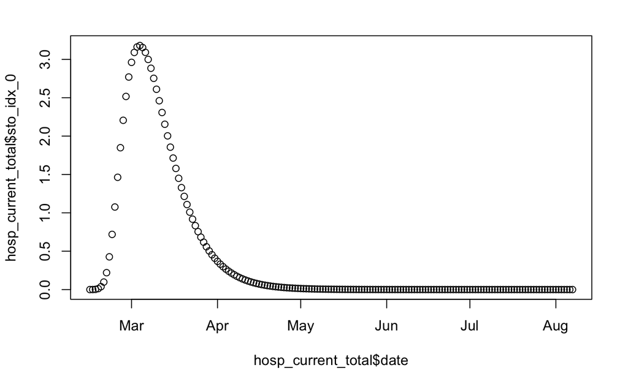

active parameters right now - sd level - infectiousness or susceptibility? - construction and UT Austin only had one age group - how to deal with a subgroup (teachers) spread over multiple age groups

Current hospitalizations vs Social distancing level - line plot - current - bar graph - cumulative - sto_idx_0 vs date - error bars: min, median, max - count scenario or rate scenario? - use rates, not counts - the other publications used counts? - colored by sd level

plots were Teachers and Staff

Import files

```r
tot_0_hcm <- read_csv("/Users/audrey/Desktop/Current Projects/COVID/teacher_SEIR-master/outputs_test/scenario_idx_0/count_scenario_idx_0_cumulative_hospitalizations_Total.csv", col_names = TRUE)

tot_1_hcm <- read_csv("/Users/audrey/Desktop/Current Projects/COVID/teacher_SEIR-master/outputs_test/scenario_idx_1/count_scenario_idx_1_cumulative_hospitalizations_Total.csv", col_names = TRUE)

tot_2_hcm <- read_csv("/Users/audrey/Desktop/Current Projects/COVID/teacher_SEIR-master/outputs_test/scenario_idx_2/count_scenario_idx_2_cumulative_hospitalizations_Total.csv", col_names = TRUE)

tot_3_hcm <- read_csv("/Users/audrey/Desktop/Current Projects/COVID/teacher_SEIR-master/outputs_test/scenario_idx_3/count_scenario_idx_3_cumulative_hospitalizations_Total.csv", col_names = TRUE)

tot_4_hcm <- read_csv("/Users/audrey/Desktop/Current Projects/COVID/teacher_SEIR-master/outputs_test/scenario_idx_4/count_scenario_idx_4_cumulative_hospitalizations_Total.csv", col_names = TRUE)
```

```r
tot_hcm <- rbind(tot_0_hcm[nrow(tot_0_hcm),], tot_1_hcm[nrow(tot_1_hcm),], tot_2_hcm[nrow(tot_2_hcm),], tot_3_hcm[nrow(tot_3_hcm),], tot_4_hcm[nrow(tot_4_hcm),])

tot_hcm <- mutate(tot_hcm, sd_level = c("0", "0.25", "0.50", "0.75", "1"))
```

does a cumulative rate even make sense? This is for “X” totals

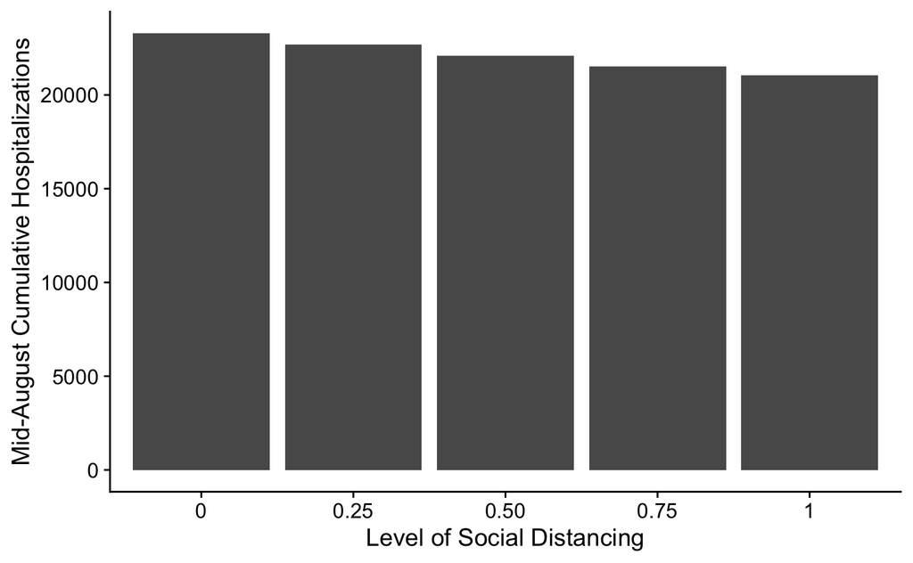

```r
ggplot(tot_hcm, aes(sd_level, sto_idx_0)) + geom_col() + xlab("Level of Social Distancing") + ylab("Mid-August Cumulative Hospitalizations") + theme_half_open()
```

Fix, use color-blind friendly palette

[figure not shown]

```r
ggplot(tot_0_hcm, aes(date, sto_idx_0)) + geom_line(color = "red") + geom_line(data = tot_1_hcm, aes(date, sto_idx_0), color = "orange") + geom_line(data = tot_2_hcm, aes(date, sto_idx_0), color = "green") + geom_line(data = tot_3_hcm, aes(date, sto_idx_0), color = "blue") + geom_line(data = tot_4_hcm, aes(date, sto_idx_0), color = "black") + theme_half_open() + xlab("Date") + ylab("Cumulative Hospitalization Rate")
```

```r
# tot_0_counth <- read_csv("/Users/audrey/Desktop/Current Projects/COVID/teacher_SEIR-master/outputs_test/scenario_idx_0/rate_scenario_idx_0_current_hospitalizations_Total.csv", col_names = TRUE)

t3_0_counth <- read_csv("/Users/audrey/Desktop/Current Projects/COVID/teacher_SEIR-master/outputs_test/scenario_idx_0/rate_scenario_idx_0_current_hospitalizations_18-25 T.csv", col_names = TRUE)

t4_0_counth <- read_csv("/Users/audrey/Desktop/Current Projects/COVID/teacher_SEIR-master/outputs_test/scenario_idx_0/rate_scenario_idx_0_current_hospitalizations_26-49 T.csv", col_names = TRUE)

t5_0_counth <- read_csv("/Users/audrey/Desktop/Current Projects/COVID/teacher_SEIR-master/outputs_test/scenario_idx_0/rate_scenario_idx_0_current_hospitalizations_50-64 T.csv", col_names = TRUE)

t6_0_counth <- read_csv("/Users/audrey/Desktop/Current Projects/COVID/teacher_SEIR-master/outputs_test/scenario_idx_0/rate_scenario_idx_0_current_hospitalizations_65+ T.csv", col_names = TRUE)
#---------------------------------------------------
x3_0_counth <- read_csv("/Users/audrey/Desktop/Current Projects/COVID/teacher_SEIR-master/outputs_test/scenario_idx_0/rate_scenario_idx_0_current_hospitalizations_18-25 X.csv", col_names = TRUE)

x4_0_counth <- read_csv("/Users/audrey/Desktop/Current Projects/COVID/teacher_SEIR-master/outputs_test/scenario_idx_0/rate_scenario_idx_0_current_hospitalizations_26-49 X.csv", col_names = TRUE)

x5_0_counth <- read_csv("/Users/audrey/Desktop/Current Projects/COVID/teacher_SEIR-master/outputs_test/scenario_idx_0/rate_scenario_idx_0_current_hospitalizations_50-64 X.csv", col_names = TRUE)

x6_0_counth <- read_csv("/Users/audrey/Desktop/Current Projects/COVID/teacher_SEIR-master/outputs_test/scenario_idx_0/rate_scenario_idx_0_current_hospitalizations_65+ X.csv", col_names = TRUE)
```

linetype = 5 add legend

Teachers vs The Rest - not the way to go w/ cumulative

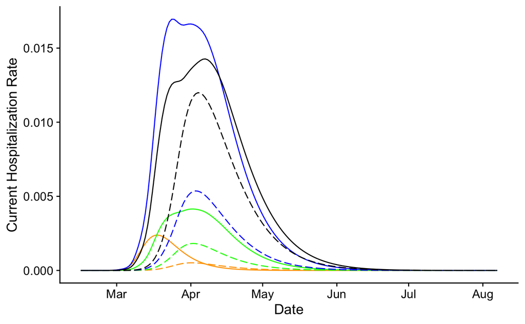

```r
ggplot() + geom_line(data = t3_0_counth, aes(date, sto_idx_0), color = "orange") + geom_line(data = t4_0_counth, aes(date, sto_idx_0), color = "green") + geom_line(data = t5_0_counth, aes(date, sto_idx_0), color = "blue") + geom_line(data = t6_0_counth, aes(date, sto_idx_0), color = "black") + geom_line(data = x3_0_counth, aes(date, sto_idx_0), color = "orange", linetype=5) + geom_line(data = x4_0_counth, aes(date, sto_idx_0), color = "green", linetype=5) + geom_line(data = x5_0_counth, aes(date, sto_idx_0), color = "blue", linetype=5) + geom_line(data = x6_0_counth, aes(date, sto_idx_0), color = "black", linetype=5) + theme_half_open() + xlab("Date") + ylab("Current Hospitalization Rate")
```

Staff vs X (same as above)

Infection Rates - T vs X - S vs X

Death Rates - T vs X - S vs X

```r
ggplot(tot_hcm, aes(sd_level, sto_idx_0)) + geom_col() + xlab("Level of Social Distancing") + ylab("Cumulative Hospitalization Rate") + theme_half_open()
```

[output not shown]